# index

### ATK vs DMG vs CRIT on Honkai: Star Rail

**TLDR**

Taking into account all possible bonus sources (relics, light cone, traces, ally buffs etc), calculate the following 3 measurements:

$$ \large \begin{align*} \text{ATK Score} &= 9 \times \left( 1 + \mathrm{ATK_{bonus}^{_{\%}}} + \frac{\mathrm{ATK_{flat}}}{\mathrm{ATK_{base}}} \right) = \underbrace{9 \times \left( 1 + \frac{\text{ATK Blue Number}}{\text{ATK Black Number}} \right)}_{\text{When there are no external ATK buffs}} \\ \text{DMG Score} &= 10 \times \left( 1 + \mathrm{DMG_{bonus}^{_{\%}}} \right) \\ \\ \text{CRIT Score} &= 6 \times \left( \frac{1}{\mathrm{Rate_{crit}^{_{\%}}}} + \mathrm{DMG_{crit}^{_{\%}}} \right) \end{align*}$$

The optimal balance between ATK vs DMG vs CRIT is achieved when ATK Score = DMG Score = CRIT Score. When not equal, your lowest score indicates the attribute your **relics** are most starved for. Try to "migrate" relic stats from your highest score to your lowest score.

**Note:** In lower investment, there are stat constraints that affect the optimization solutions (see Karush–Kuhn–Tucker conditions). In this case, ignore the CRIT Score and just use ATK Score = DMG Score while keeping $\mathrm{Rate_{crit}^{_{\%}}}$ and $\mathrm{DMG_{crit}^{_{\%}}}$ to the **smallest** possible value.

**Mathematical Proof**

Damage formula:

$$ \large \begin{align*} \mathrm{DMG_{out}} = \left[ \mathrm{ATK_{base}} \times \left( 1 + \mathrm{ATK_{bonus}^{_{\%}}} \right) + \mathrm{ATK_{flat}} \right] \times \left( 1 + \mathrm{DMG_{bonus}^{_{\%}}} \right) \times \left( 1 + \mathrm{Rate_{crit}^{_{\%}}} \times \mathrm{DMG_{crit}^{_{\%}}} \right) \end{align*} $$

- A main stat (or 10 sub-stats) is worth either:
  - 43.20% of $\mathrm{ATK_{bonus}^{_{\%}}}$
  - 38.88% of $\mathrm{DMG_{bonus}^{_{\%}}}$
  - 32.40% of $\mathrm{Rate_{crit}^{_{\%}}}$
  - 64.80% of $\mathrm{DMG_{crit}^{_{\%}}}$

$$ \large \begin{align*} \mathrm{Cost} = \frac{\mathrm{ATK_{bonus}^{_{\%}}}}{43.20\%} + \frac{\mathrm{DMG_{bonus}^{_{\%}}}}{38.88\%} + \frac{\mathrm{Rate_{crit}^{_{\%}}}}{32.40\%} + \frac{\mathrm{DMG_{crit}^{_{\%}}}}{64.80\%} \end{align*}$$

Lagrange multiplier:

$$ \nabla \mathrm{DMG_{out}} = \lambda \times \nabla \mathrm{Cost} \implies \Large \begin{cases} \frac{\partial \mathrm{DMG_{out}}}{\partial \mathrm{ATK_{bonus}^{_{\%}}}} = \lambda \frac{\partial \mathrm{Cost}}{\partial \mathrm{ATK_{bonus}^{_{\%}}}} \\ \\ \frac{\partial \mathrm{DMG_{out}}}{\partial \mathrm{DMG_{bonus}^{_{\%}}}} = \lambda \frac{\partial \mathrm{Cost}}{\partial \mathrm{DMG_{bonus}^{_{\%}}}} \\ \\ \frac{\partial \mathrm{DMG_{out}}}{\partial \mathrm{Rate_{crit}^{_{\%}}}} = \lambda \frac{\partial \mathrm{Cost}}{\partial \mathrm{Rate_{crit}^{_{\%}}}} \\ \\ \frac{\partial \mathrm{DMG_{out}}}{\partial \mathrm{DMG_{crit}^{_{\%}}}} = \lambda \frac{\partial \mathrm{Cost}}{\partial \mathrm{DMG_{crit}^{_{\%}}}} \end{cases} \implies \begin{cases} \mathrm{ATK_{base}} \times \left( 1 + \mathrm{DMG_{bonus}^{_{\%}}} \right) \times \left( 1 + \mathrm{Rate_{crit}^{_{\%}}} \times \mathrm{DMG_{crit}^{_{\%}}} \right) = \frac{\lambda}{43.20\%} && (1) \\ \\ \left[ \mathrm{ATK_{base}} \times \left( 1 + \mathrm{ATK_{bonus}^{_{\%}}} \right) + \mathrm{ATK_{flat}} \right] \times \left( 1 + \mathrm{Rate_{crit}^{_{\%}}} \times \mathrm{DMG_{crit}^{_{\%}}} \right) = \frac{\lambda}{38.88\%} && (2) \\ \\ \left[ \mathrm{ATK_{base}} \times \left( 1 + \mathrm{ATK_{bonus}^{_{\%}}} \right) + \mathrm{ATK_{flat}} \right] \times \left( 1 + \mathrm{DMG_{bonus}^{_{\%}}} \right) \times \mathrm{DMG_{crit}^{_{\%}}} = \frac{\lambda}{32.40\%} && (3) \\ \\ \left[ \mathrm{ATK_{base}} \times \left( 1 + \mathrm{ATK_{bonus}^{_{\%}}} \right) + \mathrm{ATK_{flat}} \right] \times \left( 1 + \mathrm{DMG_{bonus}^{_{\%}}} \right) \times \mathrm{Rate_{crit}^{_{\%}}} = \frac{\lambda}{64.80\%} && (4) \end{cases} $$

(3) divided by (4):

$$ \large \begin{align*} \frac{\mathrm{DMG_{crit}^{_{\%}}}}{\mathrm{Rate_{crit}^{_{\%}}}} = \frac{64.80\%}{32.40\%} = 2 \quad\implies\quad \mathrm{DMG_{crit}^{_{\%}}} = 2 \times \mathrm{Rate_{crit}^{_{\%}}} \end{align*}$$

(2) divided by (4):

$$ \large \begin{align*} \frac{1 + \mathrm{Rate_{crit}^{_{\%}}} \times \mathrm{DMG_{crit}^{_{\%}}}}{\left( 1 + \mathrm{DMG_{bonus}^{_{\%}}} \right) \times \mathrm{Rate_{crit}^{_{\%}}}} = \frac{64.80\%}{38.88\%} = \frac{10}{6} \quad\implies\quad 6 \times \left( \frac{1}{\mathrm{Rate_{crit}^{_{\%}}}} + \mathrm{DMG_{crit}^{_{\%}}} \right) = 10 \times \left( 1 + \mathrm{DMG_{bonus}^{_{\%}}} \right) \end{align*}$$

(1) divided by (4):

$$ \large \begin{align*} \frac{\mathrm{ATK_{base}} \times \left( 1 + \mathrm{Rate_{crit}^{_{\%}}} \times \mathrm{DMG_{crit}^{_{\%}}} \right)} {\left[ \mathrm{ATK_{base}} \times \left( 1 + \mathrm{ATK_{bonus}^{_{\%}}} \right) + \mathrm{ATK_{flat}} \right] \times \mathrm{Rate_{crit}^{_{\%}}}} = \frac{64.80\%}{43.20\%} = \frac{9}{6} \quad\implies\quad 6 \times \left( \frac{1}{\mathrm{Rate_{crit}^{_{\%}}}} + \mathrm{DMG_{crit}^{_{\%}}} \right) = 9 \times \left( 1 + \mathrm{ATK_{bonus}^{_{\%}}} + \frac{\mathrm{ATK_{flat}}}{\mathrm{ATK_{base}}} \right) \end{align*}$$

(2) divided by (3):

$$ \large \begin{align*} \frac{1 + \mathrm{Rate_{crit}^{_{\%}}} \times \mathrm{DMG_{crit}^{_{\%}}}}{\left( 1 + \mathrm{DMG_{bonus}^{_{\%}}} \right) \times \mathrm{DMG_{crit}^{_{\%}}}} = \frac{32.40\%}{38.88\%} = \frac{10}{12} \quad\implies\quad 12 \times \left( \frac{1}{\mathrm{DMG_{crit}^{_{\%}}}} + \mathrm{Rate_{crit}^{_{\%}}} \right) = 10 \times \left( 1 + \mathrm{DMG_{bonus}^{_{\%}}} \right) \end{align*}$$

(1) divided by (3):

$$ \large \begin{align*} \frac{\mathrm{ATK_{base}} \times \left( 1 + \mathrm{Rate_{crit}^{_{\%}}} \times \mathrm{DMG_{crit}^{_{\%}}} \right)} {\left[ \mathrm{ATK_{base}} \times \left( 1 + \mathrm{ATK_{bonus}^{_{\%}}} \right) + \mathrm{ATK_{flat}} \right] \times \mathrm{DMG_{crit}^{_{\%}}}} = \frac{32.40\%}{43.20\%} = \frac{9}{12} \quad\implies\quad 12 \times \left( \frac{1}{\mathrm{DMG_{crit}^{_{\%}}}} + \mathrm{Rate_{crit}^{_{\%}}} \right) = 9 \times \left( 1 + \mathrm{ATK_{bonus}^{_{\%}}} + \frac{\mathrm{ATK_{flat}}}{\mathrm{ATK_{base}}} \right) \end{align*}$$

(1) divided by (2):

$$ \large \begin{align*} \frac{\mathrm{ATK_{base}} \times \left( 1 + \mathrm{DMG_{bonus}^{_{\%}}} \right)}{\mathrm{ATK_{base}} \times \left( 1 + \mathrm{ATK_{bonus}^{_{\%}}} \right) + \mathrm{ATK_{flat}}} = \frac{38.88\%}{43.20\%} = \frac{9}{10} \quad\implies\quad 10 \times \left( 1 + \mathrm{DMG_{bonus}^{_{\%}}} \right) = 9 \times \left( 1 + \mathrm{ATK_{bonus}^{_{\%}}} + \frac{\mathrm{ATK_{flat}}}{\mathrm{ATK_{base}}} \right) \end{align*}$$

Therefore, the optimal balance between ATK vs DMG vs CRIT is given by:

$$ \large \begin{align*} \underbrace{9 \times \left( 1 + \mathrm{ATK_{bonus}^{_{\%}}} + \frac{\mathrm{ATK_{flat}}}{\mathrm{ATK_{base}}} \right)}_{\text{ATK Score}} = \underbrace{10 \times \left( 1 + \mathrm{DMG_{bonus}^{_{\%}}} \right)}_{\text{DMG Score}} = \underbrace{6 \times \left( \frac{1}{\mathrm{Rate_{crit}^{_{\%}}}} + \mathrm{DMG_{crit}^{_{\%}}} \right)}_{\text{CRIT Score}} \end{align*}$$

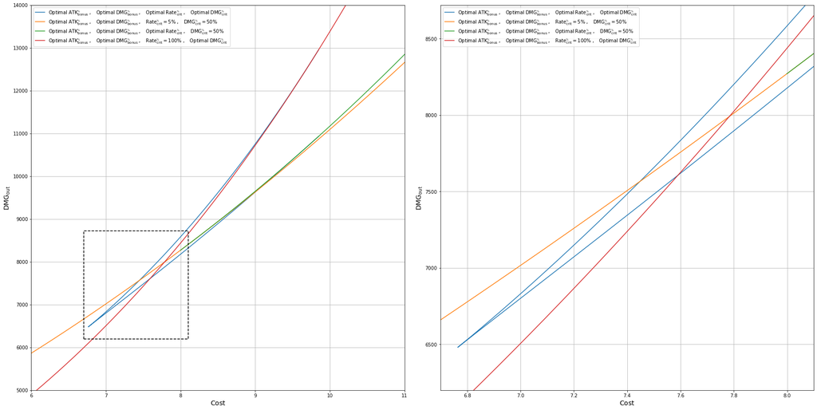

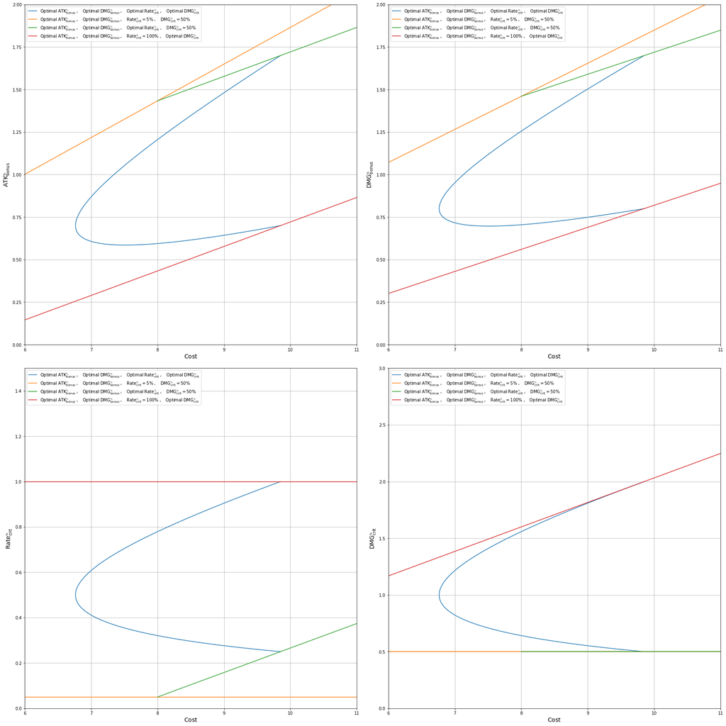

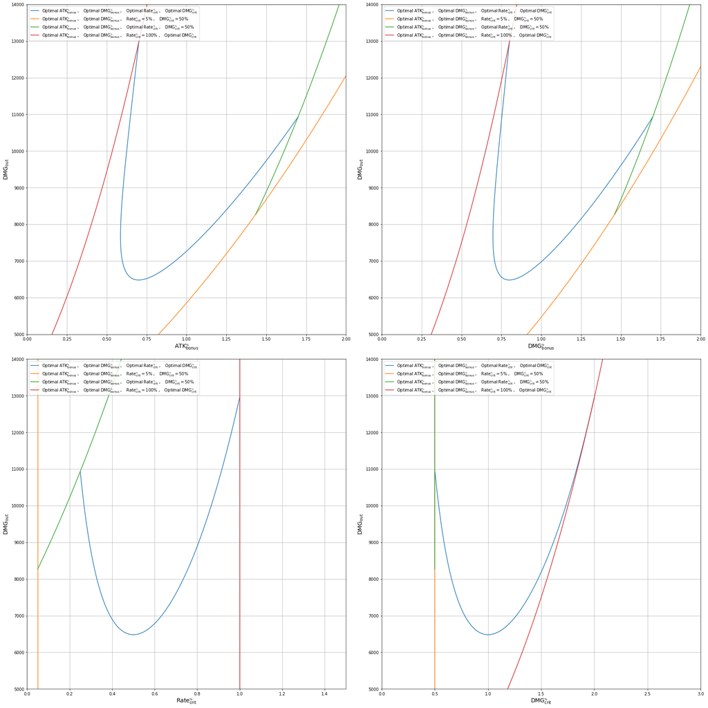

```python
import numpy as np
from matplotlib import pyplot, cm

base_ATK = 1200
flat_ATK = 360

curves = []

curve = {'label': r'$\mathrm{Optimal\; ATK_{bonus}^{_{\%}}} \;,\quad \mathrm{Optimal\; DMG_{bonus}^{_{\%}}} \;,\quad \mathrm{Optimal\; Rate_{crit}^{_{\%}}} \;,\quad \mathrm{Optimal\; DMG_{crit}^{_{\%}}}$'}
curve['crit_Rate'] = np.linspace(0.25, 1.0, 1000)
curve['crit_DMG'] = 2 * curve['crit_Rate']
curve['score'] = 6 * (curve['crit_DMG'] + 1/curve['crit_Rate'])
curves.append(curve)

curve = {'label': r'$\mathrm{Optimal\; ATK_{bonus}^{_{\%}}} \;,\quad \mathrm{Optimal\; DMG_{bonus}^{_{\%}}} \;,\quad \mathrm{Rate_{crit}^{_{\%}}} = 5\% \;,\quad \mathrm{DMG_{crit}^{_{\%}}} = 50\%$'}
curve['crit_Rate'] = np.full(1000, 0.05)
curve['crit_DMG'] = np.full(1000, 0.5)
curve['score'] = np.linspace(1.0, 50.0, 1000)
curves.append(curve)

curve = {'label': r'$\mathrm{Optimal\; ATK_{bonus}^{_{\%}}} \;,\quad \mathrm{Optimal\; DMG_{bonus}^{_{\%}}} \;,\quad \mathrm{Optimal\; Rate_{crit}^{_{\%}}} \;,\quad \mathrm{DMG_{crit}^{_{\%}}} = 50\%$'}
curve['crit_Rate'] = np.linspace(0.05, 1.0, 1000)
curve['crit_DMG'] = np.full(1000, 0.5)
curve['score'] = 12 * (curve['crit_Rate'] + 1/curve['crit_DMG'])
curves.append(curve)

curve = {'label': r'$\mathrm{Optimal\; ATK_{bonus}^{_{\%}}} \;,\quad \mathrm{Optimal\; DMG_{bonus}^{_{\%}}} \;,\quad \mathrm{Rate_{crit}^{_{\%}}} = 100\% \;,\quad \mathrm{Optimal\; DMG_{crit}^{_{\%}}}$'}
curve['crit_Rate'] = np.full(1000, 1.0)
curve['crit_DMG'] = np.linspace(0.5, 3.0, 1000)
curve['score'] = 6 * (curve['crit_DMG'] + 1/curve['crit_Rate'])
curves.append(curve)

for curve in curves:
    curve['bonus_ATK'] = curve['score']/9 - 1 - flat_ATK/base_ATK
    curve['bonus_DMG'] = curve['score']/10 - 1
    curve['out_DMG'] = (base_ATK * (1 + curve['bonus_ATK']) + flat_ATK) * (1 + curve['bonus_DMG']) * (1 + curve['crit_Rate'] * curve['crit_DMG'])
    curve['cost'] = curve['bonus_ATK']/0.4320 + curve['bonus_DMG']/0.3888 + curve['crit_Rate']/0.3240 + curve['crit_DMG']/0.6480



def plot(ax, curves, x, xlim, y, ylim):
    label_LaTeX = {'out_DMG': r'$\mathrm{DMG_{out}}$', 'cost': r'$\mathrm{Cost}$',
                   'bonus_ATK': r'$\mathrm{ATK_{bonus}^{_{\%}}}$', 'bonus_DMG': r'$\mathrm{DMG_{bonus}^{_{\%}}}$',
                   'crit_Rate': r'$\mathrm{Rate_{crit}^{_{\%}}}$', 'crit_DMG': r'$\mathrm{DMG_{crit}^{_{\%}}}$'}

    ax.set_xlabel(label_LaTeX[x], fontsize=14)
    ax.set_ylabel(label_LaTeX[y], fontsize=14)

    ax.set_xlim(xlim)
    ax.set_ylim(ylim)

    for curve in curves:
        ax.plot(curve[x], curve[y], label=curve['label'])

    ax.grid()
    ax.legend(loc='upper left')

fig, axs = pyplot.subplots(1, 2, constrained_layout=True, figsize=(24, 12))
plot(axs[0], curves, 'cost', [6.0, 11.0], 'out_DMG', [5000.0, 14000.0])
plot(axs[1], curves, 'cost', [6.7, 8.1], 'out_DMG', [6200.0, 8720.0])
axs[0].plot([6.7, 6.7, 8.1, 8.1, 6.7], [6200.0, 8720.0, 8720.0, 6200.0, 6200.0], 'k--')

fig, axs = pyplot.subplots(2, 2, constrained_layout=True, figsize=(24, 24))
plot(axs[0, 0], curves, 'cost', [6.0, 11.0], 'bonus_ATK', [0, 2.0])
plot(axs[0, 1], curves, 'cost', [6.0, 11.0], 'bonus_DMG', [0, 2.0])
plot(axs[1, 0], curves, 'cost', [6.0, 11.0], 'crit_Rate', [0, 1.5])
plot(axs[1, 1], curves, 'cost', [6.0, 11.0], 'crit_DMG', [0, 3.0])

fig, axs = pyplot.subplots(2, 2, constrained_layout=True, figsize=(24, 24))
plot(axs[0, 0], curves, 'bonus_ATK', [0, 2.0], 'out_DMG', [5000.0, 14000.0])
plot(axs[0, 1], curves, 'bonus_DMG', [0, 2.0], 'out_DMG', [5000.0, 14000.0])
plot(axs[1, 0], curves, 'crit_Rate', [0, 1.5], 'out_DMG', [5000.0, 14000.0])
plot(axs[1, 1], curves, 'crit_DMG', [0, 3.0], 'out_DMG', [5000.0, 14000.0])
```